# GAMLSS Modeling with Advanced Flexible Infrastructures

Mikis Stasinopoulos, Robert Rigby, Nikolaus Umlauf

## Overview

The primary purpose of this package is to facilitate the creation of advanced infrastructures designed to enhance the GAMLSS modeling framework. Notably, the *gamlss2* package represents a significant overhaul of its predecessor, *gamlss*, with a key emphasis on improving estimation speed and incorporating more flexible infrastructures. These enhancements enable the seamless integration of various algorithms into GAMLSS, including gradient boosting, Bayesian estimation, regression trees, and forests, fostering a more versatile and powerful modeling environment.

Moreover, the package expands its compatibility by supporting all model terms from the base R *mgcv* package. Additionally, the *gamlss2* package introduces the capability to accommodate more than four parameter families. Essentially, this means that users can now specify any type of model using these new infrastructures, making the package highly flexible and accommodating to a wide range of modeling requirements.

## Installation

The development version of *gamlss2* is hosted on github at https://github.com/gamlss-dev/gamlss2. It can be installed via

```r
devtools::install_github("gamlss-dev/gamlss2")
```

## Introduction

This section gives a first quick overview of the functionality of the package and demonstrates that the usual “look & feel” when using well-established model fitting functions like `glm()` is an elementary part of *gamlss2*, i.e., first steps and basic handling of the package should be relatively simple. We illustrate the first steps with *gamlss2* using a data set taken from the *Regression Book* (Fahrmeir et al. 2021) which is about prices of used VW Golf cars. The data is loaded with

```r
data("Golf", package = "bamlss")
head(Golf)
```

```
##   price age kilometer tia abs sunroof
## 1  7.30  73        10  12 yes     yes
## 2  3.85 115        30  20 yes      no
## 3  2.95 127        43   6  no     yes
## 4  4.80 104        54  25 yes     yes
## 5  6.20  86        57  23  no      no
## 6  5.90  74        57  25 yes      no
```

In this example the aim is to model the `price` in 1000 Euro. Using *gamlss2* a first linear model could be set up by first specifying a model formula

```r
f <- price ~ age + kilometer + tia + abs + sunroof
```

afterwards the model is estimated by

```r
library("gamlss2")
b1 <- gamlss2(f, family = NO, data = Golf)
```

```
## GAMLSS-RS iteration  1: Global Deviance = 394.949 eps = 0.298244
GAMLSS-RS iteration  2: Global Deviance = 394.949 eps = 0.000000
```

The summary statistics can be shown with

```r
summary(b1)
```

```
## Call:
## gamlss2(formula = f, data = Golf, family = NO)
## ---
## Family: NO
## Link function: mu = identity, sigma = log
## *--------
## Parameter: mu
## ---
## Coefficients:
##              Estimate Std. Error t value Pr(>|t|)
## (Intercept)  9.311171   0.405779  22.946  < 2e-16 ***
## age         -0.038329   0.003345 -11.460  < 2e-16 ***
## kilometer   -0.009742   0.001424  -6.840 1.47e-10 ***
## tia         -0.005483   0.008448  -0.649   0.5172
## absyes      -0.237664   0.127244  -1.868   0.0636 .
## sunroofyes  -0.009862   0.136466  -0.072   0.9425
## *--------
## Parameter: sigma
## ---
## Coefficients:
##             Estimate Std. Error t value Pr(>|t|)
## (Intercept) -0.27083    0.05392  -5.023 1.31e-06 ***
## ---
## Signif. codes:  0 '***' 0.001 '**' 0.01 '*' 0.05 '.' 0.1 ' ' 1
## *--------
## n = 172 df =  7 res.df =  165
## Deviance = 394.949 Null Dev. Red. = 29.82%
## AIC = 408.949 elapsed =  0.02sec
```

For comparison, we estimate the same model using the *gamlss* package.

```r
library("gamlss")
b2 <- gamlss(f, family = NO, data = Golf)
```

```
## GAMLSS-RS iteration 1: Global Deviance = 394.949
## GAMLSS-RS iteration 2: Global Deviance = 394.949
```

```r
summary(b2)
```

```
## Family:  c("NO", "Normal")
##
## Call:  gamlss(formula = f, family = NO, data = Golf)
##
## Fitting method: RS()
##
## ------------------------------------------------------------------
## Mu link function:  identity
## Mu Coefficients:
##              Estimate Std. Error t value Pr(>|t|)
## (Intercept)  9.311171   0.405779  22.946  < 2e-16 ***
## age         -0.038329   0.003345 -11.460  < 2e-16 ***
## kilometer   -0.009742   0.001424  -6.840 1.47e-10 ***
## tia         -0.005483   0.008448  -0.649   0.5172
## absyes      -0.237664   0.127244  -1.868   0.0636 .
## sunroofyes  -0.009862   0.136466  -0.072   0.9425
## ---
## Signif. codes:  0 '***' 0.001 '**' 0.01 '*' 0.05 '.' 0.1 ' ' 1
##
## ------------------------------------------------------------------
## Sigma link function:  log
## Sigma Coefficients:
##             Estimate Std. Error t value Pr(>|t|)
## (Intercept) -0.27083    0.05392  -5.023 1.31e-06 ***
## ---
## Signif. codes:  0 '***' 0.001 '**' 0.01 '*' 0.05 '.' 0.1 ' ' 1
##
## ------------------------------------------------------------------
## No. of observations in the fit:  172
## Degrees of Freedom for the fit:  7
##       Residual Deg. of Freedom:  165
##                       at cycle:  2
##
## Global Deviance:     394.949
##             AIC:     408.949
##             SBC:     430.9814
```

Note that the estimated coefficients for both implementations, as well as standard errors and p-values are almost the same. Similar for confidence intervals, we get

```r
confint(b1)
```

```
##                          2.5%        97.5%
## mu.(Intercept)     8.51585890 10.106482975
## mu.age            -0.04488415 -0.031773411
## mu.kilometer      -0.01253335 -0.006950669
## mu.tia            -0.02204193  0.011074973
## mu.absyes         -0.48705708  0.011729804
## mu.sunroofyes     -0.27733137  0.257607209
## sigma.(Intercept) -0.37650522 -0.165157004
```

```r
confint(b2)
```

```
##                         2.5 %       97.5 %
## mu.(Intercept)     8.51585890 10.106482975
## mu.age            -0.04488415 -0.031773411
## mu.kilometer      -0.01253335 -0.006950669
## mu.tia            -0.02204193  0.011074973
## mu.absyes         -0.48705708  0.011729805
## mu.sunroofyes     -0.27733137  0.257607209
## sigma.(Intercept) -0.37650522 -0.165157004
```

## Munich Rent GAMLSS

To illustrate the functionality of the *gamlss2* package, we use the *rent99* dataset, which is included in the *gamlss.data* package.

```r
data("rent99", package = "gamlss.data")
```

We estimate models using the *GA* distribution.

```r
## Model formula.
f <- rent ~ s(area) + s(yearc) + location + bath + kitchen |
   s(area) + s(yearc) + location + bath + kitchen

## Estimation.
start <- proc.time()
b1 <- gamlss2(f, data = rent99, family = GA)
```

```
## GAMLSS-RS iteration  1: Global Deviance = 38445.7719 eps = 0.055723
GAMLSS-RS iteration  2: Global Deviance = 38419.413 eps = 0.000685
GAMLSS-RS iteration  3: Global Deviance = 38419.1931 eps = 0.000005
```

```r
proc.time() - start
```

```
##    user  system elapsed
##   0.434   0.000   0.434
```

```r
## Estimation with gamlss.
start <- proc.time()
b2 <- gamlss(rent ~ pb(area) + pb(yearc) + location + bath + kitchen,
  sigma.formula =~ pb(area) + pb(yearc) + location + bath + kitchen,
  data = rent99, family = GA)
```

```
## GAMLSS-RS iteration 1: Global Deviance = 38459.65
## GAMLSS-RS iteration 2: Global Deviance = 38448.8
## GAMLSS-RS iteration 3: Global Deviance = 38448.64
## GAMLSS-RS iteration 4: Global Deviance = 38448.62
## GAMLSS-RS iteration 5: Global Deviance = 38448.62
```

```r
proc.time() - start
```

```
##    user  system elapsed
##   7.355   0.028   7.382
```

```r
## Compare using the AIC.
AIC(b1, b2)
```

```
##          df      AIC
## b1 36.52459 38492.24
## b2 25.38180 38499.38
```

Note that *gamlss2* is considerably faster in this example. Estimated effects can be visualized with

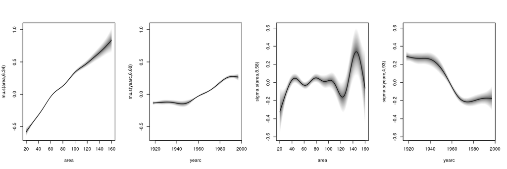

```r
plot(b1)
```

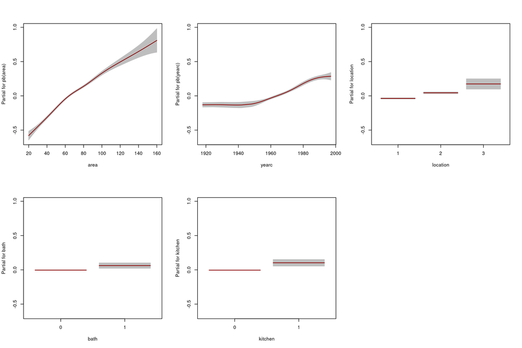

```r
term.plot(b2, what = "mu", pages = 1, ask = FALSE)
```

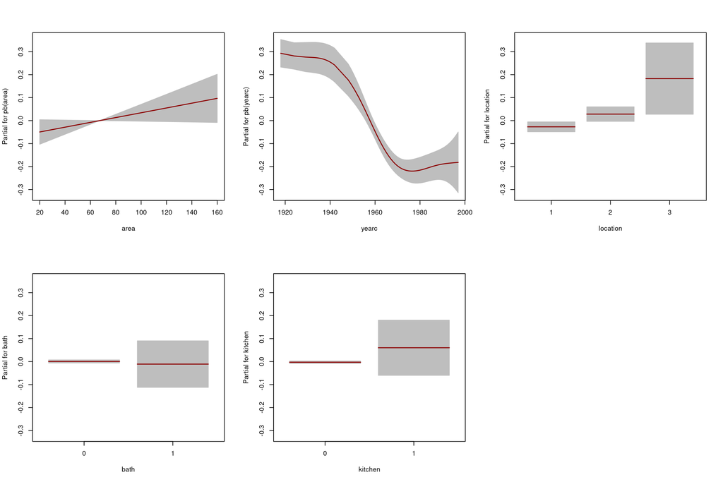

```r
term.plot(b2, what = "sigma", pages = 1, ask = FALSE)
```

## Big Data

To optimize computational efficiency when working with large datasets, we leverage the observation that the number of distinct observations for a given covariate is typically significantly smaller than the total number of observations in the complete dataset. As a strategy, we calculate design matrices only using these unique observations and implement the exceptionally efficient algorithms presented in Lang et al. (2012). This option can be used by setting the argument `binning = TRUE`. In many instances, it is feasible to decrease the number of distinct observations through rounding, such as rounding to two digits. In the context of large datasets, the approximation error associated with this rounding is typically negligible.

Below, we present an example utilizing precipitation data obtained from German meteorological stations, provided by the Deutscher Wetterdienst (DWD, https://www.dwd.de/). In this illustration, we employ a censored normal distribution to model precipitation amounts, which can be constructed using the *gamlss.cens* package.

```r
library("gamlss.cens")
gen.cens(NO, type = "left")
```

```
## A censored family of distributions from NO has been generated
##  and saved under the names:
##  dNOlc pNOlc qNOlc NOlc
## The type of censoring is left
```

The compiled data set is available at [WeatherGermany.rds](https://fileshare.uibk.ac.at/f/795c0a9739de4e06b3a5/?dl=1) and contains the following covariates

```r
d <- readRDS("WeatherGermany.rds")
print(dim(d))
```

```
## [1] 1187507      12
```

```r
print(head(d))
```

```
##       ID   Name       Date year mon yday alt    lon     lat    T  Pre Wmax
## 44742  3 Aachen 1981-01-01 1981   0    0 202 6.0941 50.7827  3.4  4.5 20.6
## 44743  3 Aachen 1981-01-02 1981   0    1 202 6.0941 50.7827  5.8 17.6 19.6
## 44744  3 Aachen 1981-01-03 1981   0    2 202 6.0941 50.7827  6.6 10.6 27.3
## 44745  3 Aachen 1981-01-04 1981   0    3 202 6.0941 50.7827  1.4  4.9 19.0
## 44746  3 Aachen 1981-01-05 1981   0    4 202 6.0941 50.7827  0.8  5.4 11.3
## 44747  3 Aachen 1981-01-06 1981   0    5 202 6.0941 50.7827 -0.1  2.1 11.8
```

The model can be estimated with

```r
## Create indicator for Surv() response.
d$cens <- d$Pre > 0

## Model formula.
f <- ~ s(year) + s(alt,k=4) +
  ti(yday,bs="cc") + ti(lon,lat,bs="tp",d=2,k=30) +
  ti(yday,lon,lat,bs=c("cc","tp"),d=c(1,2),k=c(10,30))

f <- rep(list(f), 2)
f[[1]] <- update(f[[1]], Surv(sqrt(Pre), cens, type = "left") ~ .)

## Estimate model.
b <- gamlss2(f, data = d, family = NOlc,
  binning = TRUE, light = TRUE, flush = FALSE)
```

Please be aware that setting the argument `light = TRUE` results in the exclusion of all design matrices, the model frame, and fitted values from the returned object. This is done to minimize the object’s size. Note that the model is quite complex, as it includes a three dimensional seasonal varying spatial effect.

The summary statistics gives

```r
summary(b)
```

```
## Call:
## gamlss2(formula = Surv(sqrt(Pre), cens, type = "left") ~ s(year) +
##     s(alt, k = 4) + ti(yday, bs = "cc") + ti(lon, lat, bs = "tp",
##     d = 2, k = 30) + ti(yday, lon, lat, bs = c("cc", "tp"), d = c(1,
##     2), k = c(10, 30)) | s(year) + s(alt, k = 4) + ti(yday, bs = "cc") +
##     ti(lon, lat, bs = "tp", d = 2, k = 30) + ti(yday, lon, lat,
##     bs = c("cc", "tp"), d = c(1, 2), k = c(10, 30)), data = d,
##     family = NOlc, ... = pairlist(x = FALSE, binning = TRUE, light = TRUE, flush = FALSE))
## ---
## Family: NOlc
## Link function: mu = identity, sigma = log
## *--------
## Parameter: mu
## ---
## Coefficients:
##             Estimate Std. Error t value Pr(>|t|)
## (Intercept) 0.072359   0.002266   31.93   <2e-16 ***
## ---
## Smooth terms:
##     s(year)  s(alt) ti(yday) ti(lon,lat) ti(yday,lon,lat)
## edf  8.9818  2.9404   2.9994     28.4035           185.44
## *--------
## Parameter: sigma
## ---
## Coefficients:
##              Estimate Std. Error t value Pr(>|t|)
## (Intercept) 0.6864159  0.0009978   687.9   <2e-16 ***
## ---
## Signif. codes:  0 '***' 0.001 '**' 0.01 '*' 0.05 '.' 0.1 ' ' 1
## ---
## Smooth terms:
##     s(year)  s(alt) ti(yday) ti(lon,lat) ti(yday,lon,lat)
## edf  8.9604  2.9924   2.9999     28.7177           133.63
## *--------
## n = 1187507 df =  408.06 res.df =  1187098.94
## Deviance = 3374960.2202 Null Dev. Red. = 1.46%
## AIC = 3375776.3449 elapsed =  9.86min
```

Visualize estimated effects

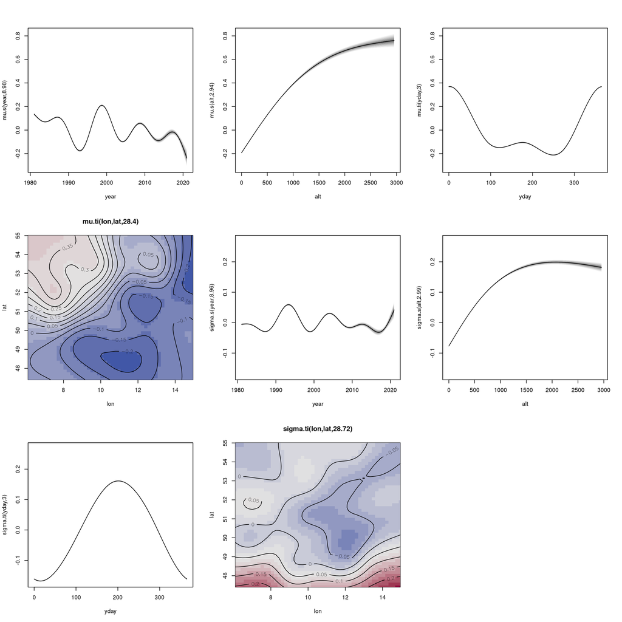

```r
plot(b, image = TRUE)
```

## Exchanging the Optimizer

The default optimizer function in *gamlss2* is `RS()`. The function has arguments

```r
RS(x, y, specials, family, offsets, weights, xterms, sterms, control)
```

where `x` is the linear effects design matrix, `y` is the response (a vector or matrix), `specials` is a named list of special model terms, e.g., as created by smooth constructor `s()`. Now `xterms` and `sterms` are named lists, each list element represents one parameter of the distribution as specified in the `family`. One list elements holds the variable names of linear effects or the term labels of specials (smooth) model terms. This way, no duplicated design matrices need to be setup.

The return value of `RS()` is of class `"gamlss2"` for which summary, extractor and plotting functions are provided.

Note that function `RS()`may be exchanged, either using `gamlss2_control()` or if an `$optimizer` function is specified within the family. This way, one could also integrate full Bayesian MCMC methods, or boosting algorithms etc. Only the methods for the return value need to be written new for such functions.

## New Special Terms

In similar fashion new “special” model terms can be included for `RS()`and `GC()`. All is needed is to write methods for

```r
special_fit(x, ...)
special_predict(x, ...)
```

where `x` is a model term object as supplied in the formula in the `gamlss2()` call.

Example using existing `smooth.construct()` infrastructures, new `pb2()` model term

```r
pb2 <- function(x, df = NULL, lambda = NULL, max.df = NULL, control = pb2.control(...), ...)
{
  m <- c(control$degree, control$order)
  k <- control$inter + m[1L] + 1L
  sx <- s(x, bs = "ps", m = m, k = k, sp = lambda)
  sx$control <- control
  sx$label <- gsub("s(", "pb2(", sx$label, fixed = TRUE)
  sx$orig.label <- sx$label
  sx$localML <- TRUE
  return(sx)
}
```

Or, completely new model term, e.g., conditional inference forest constructor.

```r
## Special conditional inference forest constructor.
cf <- function(formula, ...)
{
  stopifnot(requireNamespace("partykit"))
  st <- list()
  ctr <- list(...)
  ntree <- ctr$ntree
  if(is.null(ntree))
    ntree <- 100L
  ctr$ntree <- NULL
  st$control <- do.call(partykit::ctree_control, ctr)
  st$formula <- formula
  st$term <- all.vars(formula)
  st$label <- paste0("cf(", paste0(gsub(" ", "", as.character(formula)), collapse = ""), ")")
  st$data <- model.frame(formula)
  st$ntree <- ntree
  class(st) <- c("special", "cf")
  return(st)
}

## The fitting function for the backfitting algorithm.
special_fit.cf <- function(x, z, w, y, eta, j, family, control, ...)
{
  f <- update(x$formula, response_z ~ .)
  x$data$response_z <- z
  rval <- list(
    "model" = partykit::cforest(formula = f, data = x$data, weights = w,
      control = x$control, ntree = x$ntree)
  )
  rval$fitted.values <- predict(rval$model)
  rval$shift <- mean(rval$fitted.values)
  rval$fitted.values <- rval$fitted.values - rval$shift
  rval$edf <- x$ntree
  class(rval) <- "cf.fitted"
  return(rval)
}

## Predict method.
special_predict.cf.fitted <- function(x, data, se.fit = FALSE, ...)
{
  if(se.fit) {
    ct <- lapply(seq_along(x$model$nodes), function(i) partykit::as.constparty(
      partykit::party(x$model$nodes[[i]], data = x$model$data, terms = x$model$terms,
      fitted = data.frame(
        `(response)` = x$model$fitted[["(response)"]],
        `(weights)` = x$model$weights[[i]],
        check.names = FALSE))
    ))
    p <- sapply(ct, predict, newdata = data)
    p <- apply(p, 1, quantile, prob = c(0.05, 0.5, 0.95))
    p <- t(p)
    colnames(p) <- c("lower", "fit", "upper")
  } else {
    p <- predict(x$model, newdata = data, type = "response")
  }
  p <- p - x$shift
  return(p)
}
```

Similar, a neural network model term, see `?special_terms`.

## Notes

- Package *gamlss* “special” model terms in *gamlss2*? Support is already there but limited, e.g., using `pb()` confidence intervals cannot be computed.
- Write wrappers like `pb2()`, use `smooth.construct()`?
- Goal is to write more optimizer/sampler functions.
- Project idea, “non-cyclic” algorithm for fast stepwise selection of linear or smooth terms?
- `predict()` with confidence/prediction intervals? `se.fit = TRUE` does not work using new data?
- How should we compute confidence/prediction intervals?
- Considering *gamlss*, extend the examples similar to *gamlss2*.
- Check the manual pages carefully, e.g., do we need references on every manual page?
- Include the `NO()` distribution in *gamlss* (or hidden default `.NO()`) so we can write examples for each family in *gamlss.dist*?

## References

Fahrmeir, Ludwig, Thomas Kneib, Stefan Lang, and Brian Marx. 2021. *Regression – Models, Methods and Applications*. 2nd ed. Berlin: Springer-Verlag. https://doi.org/10.1007/978-3-662-63882-8.

Lang, Stefan, Nikolaus Umlauf, Peter Wechselberger, Kenneth Harttgen, and Thomas Kneib. 2012. “Multilevel Structured Additive Regression.” *Statistics and Computing* 24 (2): 223–38. https://doi.org/10.1007/s11222-012-9366-0.